[figure not shown]

# Pesquisa de Egressos da Graduação Ano-base 2021 — RAIS 2021

Diretoria de Avaliação e Informações Gerenciais - DAI Decanato de Planejamento, Orçamento e Avaliação Institucional - DPO Universidade de Brasília - UnB

Última atualização: 20/07/2023

# Introdução

O acompanhamento de egressos representa a oportunidade de mensurar o impacto de um dos principais produtos oferecidos pela UnB: a formação universitária. Esse retorno é fundamental para avaliar as qualidades dos cursos, para a formulação de políticas institucionais e para conhecer os resultados do compromisso da UnB com a sociedade.

Todos os relatórios, de cada curso e nível (graduação e pós-graduação), são disponibilizados publicamente no site Avaliação UnB . Com este Relatório, o DPO possibilita aos colegiados de graduação, núcleos docente estruturante (NDE), unidades acadêmicas e Administração Superior novas reflexões sobre currículos e formação ofertadas, tendo em vista a missão institucional da Universidade.

# Metodologia

A identificação dos egressos da UnB obedece a dois critérios principais:

1. estudantes que ingressaram na UnB e saíram da graduação, por formatura ou evasão, até o ano de 2021, tendo como ponto de partida o início dos registros acadêmicos nos sistemas da UnB; e
2. profissionais que estão presentes na RAIS 2021, não sendo apresentados dados comparativos sobre remuneração mensal média dos egressos antes dos estudos de graduação na UnB. Foram considerados apenas os cursos presenciais.

As formas de saída foram condensadas em duas categorias: Formado e Desligado. As remunerações foram calculadas considerando todos os vínculos ativos de trabalho, por egresso, com o devido ponderamento para os meses em que houve vínculo ativo no ano em referência, de acordo com os registros da RAIS. Em todas as tabelas que tratam da remuneração mensal média foram dispostas, também, as estatísticas de desvio-padrão e coeficiente de variação, com o objetivo de melhorar a análise da variabilidade dos dados — em linhas gerais, quanto maior o desvio-padrão, maior a variabilidade dos dados, ou seja, a média apresentada está sendo afetada por valores extremos. Já o coeficiente de variação, como medida relativa de variabilidade, é utilizado para complementar a interpretação do desvio-padrão e comparar com outros coeficientes de variação — quanto menor, menor a variação daquela média.

Com atenção à privacidade dos egressos, todas as tabelas de remuneração mensal média omitem os casos em que haja apenas uma observação, de forma a não permitir a identificação de casos específicos.

Por fim, foram identificados os nossos egressos que trabalham na UnB nas carreiras de docente ou técnico-administrativo em educação (TAE), utilizando a base de servidores da UnB, de responsabilidade do Decanato de Gestão de Pessoas (DGP) — tais entradas foram destacadas em **negrito** nas tabelas de remuneração mensal média por profissão.

# Resultados

O curso de graduação em Educação do Campo, opção Linguagens, Artes E Literatura, grau Licenciatura teve, até o ano de 2021, 714 egressos únicos, de acordo com os registros institucionais. Os registros da RAIS de 2021 mostram que, desse total, 269 egressos tinham vínculo formal (37,68%). A turma mais antiga de egressos localizada na RAIS 2021 data de 2007 e a mais recente, de 2018. A tabela abaixo descreve melhor a representatividade dos egressos, por ano de ingresso.

Tabela 1: Caracterização dos egressos pelo ano de ingresso

| ANO DE INGRESSO | TOTAL DE EGRESSOS | EGRESSOS LOCALIZADOS NA RAIS | REPRESENTATIVIDADE |
| --- | --- | --- | --- |
| 2007 | 61 | 38 | 62,30% |
| 2008 | 50 | 31 | 62,00% |
| 2009 | 60 | 39 | 65,00% |
| 2010 | 55 | 32 | 58,18% |
| 2011 | 60 | 42 | 70,00% |
| 2012 | 55 | 34 | 61,82% |
| 2014 | 58 | 21 | 36,21% |
| 2015 | 39 | 11 | 28,21% |
| 2016 | 56 | 8 | 14,29% |
| 2018 | 158 | 13 | 8,23% |
| 2019 | 2 | 0 | 0,00% |
| 2020 | 60 | 0 | 0,00% |

O tempo desde a formatura é outra variável de interesse para melhor qualificar o perfil do egresso, especificamente daquele que saiu da UnB por formatura na graduação. O tempo médio, em anos, desde sua formatura, é de **7,7** e a mediana é **8**.

Tabela 2: Distribuição dos egressos formados pelo tempo desde sua formatura na graduação

| TEMPO DESDE A FORMATURA | EGRESSOS FORMADOS |
| --- | --- |
| De 2 a 5 anos | 15 (16,7%) |
| De 6 a 10 anos | 66 (73,3%) |
| De 11 a 20 anos | 9 (10,0%) |
| Total | 90 (100,0%) |

Em complementação ao tempo desde a formatura, tem-se também o tempo médio e mediano, **em semestres**, que os egressos mantiveram-se no curso, até a finalização ou evasão.

Tabela 3: Estatísticas do tempo (semestres) que os egressos ficaram no curso

| FORMA DE SAÍDA | MÉDIA | MEDIANA |
| --- | --- | --- |
| Desligado | 5,41 | 5 |
| Formado | 10,47 | 10 |

Outra informação relevante sobre os egressos que evadiram do curso de Educação do Campo, opção Linguagens, Artes E Literatura, é a possibilidade do egresso ter se formado em outro curso da UnB **antes** da ocorrência de evasão.

Tabela 4: Distribuição dos egressos evadidos por situação de formatura anterior

| SITUAÇÃO DO EGRESSO | TOTAL |
| --- | --- |
| SEM formatura em outro curso da UnB | 179 (100,0%) |
| Total | 179 (100,0%) |

Há também a possibilidade de algum egresso já ter formatura em algum programa de pós-graduação da UnB, nos níveis mestrado ou doutorado, até o ano de referência deste estudo.

Tabela 5: Distribuição dos egressos por situação de formatura em pós-graduação

| SITUAÇÃO DO EGRESSO | TOTAL |
| --- | --- |
| SEM pós-graduação na UnB | 261 (97,0%) |
| COM pós-graduação na UnB | 8 (3,0%) |
| Total | 269 (100,0%) |

O número de vínculos empregatícios dos egressos é algo que também foi considerado - a média de empregos, por pessoa, é de **1,152**. Deve-se destacar que, nos casos de mais de um trabalho, não quer dizer que sejam todos ativos - pode ter ocorrido uma troca de emprego. Nesses casos, a devida ponderação por tempo de serviço foi aplicada.

Tabela 6: Distribuição dos vínculos empregatícios por egresso

| NÚMERO DE EMPREGOS | NÚMERO DE EGRESSOS |
| --- | --- |
| Um | 229 |
| Dois | 39 |
| Três | 1 |

## Perfil dos Egressos por Forma de Saída

Tabela 7: Distribuição por intervalo de tempo, em semestres, até a saída do curso

| INTERVALO DE TEMPO ATÉ A SAÍDA | DESLIGADO | FORMADO | TOTAL |
| --- | --- | --- | --- |
| Menor ou igual à DPC | 171 (95,5%) | 66 (73,3%) | 237 (88,1%) |
| Até dois semestres além da DPC | 4 (2,2%) | 15 (16,7%) | 19 (7,1%) |
| Três semestres ou mais além da DPC | 4 (2,2%) | 9 (10,0%) | 13 (4,8%) |
| Total | 179 (100,0%) | 90 (100,0%) | 269 (100,0%) |

Notas:  
DPC: Duração Padrão do Curso, de acordo com a SESu/MEC.

Tabela 8: Distribuição por sexo e forma de saída

| SEXO | DESLIGADO | FORMADO | TOTAL |
| --- | --- | --- | --- |
| Feminino | 100 (57,5%) | 74 (42,5%) | 174 (100,0%) |
| Masculino | 79 (83,2%) | 16 (16,8%) | 95 (100,0%) |
| Total | 179 (66,5%) | 90 (33,5%) | 269 (100,0%) |

Tabela 9: Distribuição por faixa etária (na data de referência) e forma de saída

| FAIXA ETÁRIA | DESLIGADO | FORMADO | TOTAL |
| --- | --- | --- | --- |
| Até 24 anos | 2 (100,0%) | 0 (0,0%) | 2 (100,0%) |
| De 25 a 29 anos | 39 (73,6%) | 14 (26,4%) | 53 (100,0%) |
| De 30 a 34 anos | 53 (70,7%) | 22 (29,3%) | 75 (100,0%) |
| De 35 a 39 anos | 31 (59,6%) | 21 (40,4%) | 52 (100,0%) |
| De 40 a 44 anos | 25 (62,5%) | 15 (37,5%) | 40 (100,0%) |
| De 45 anos ou mais | 29 (61,7%) | 18 (38,3%) | 47 (100,0%) |
| Total | 179 (66,5%) | 90 (33,5%) | 269 (100,0%) |

Tabela 10: Distribuição por faixa etária (no ano de saída) e forma de saída

| FAIXA ETÁRIA | DESLIGADO | FORMADO | TOTAL |
| --- | --- | --- | --- |
| Até 18 anos | 1 (100,0%) | 0 (0,0%) | 1 (100,0%) |
| De 19 a 24 anos | 62 (82,7%) | 13 (17,3%) | 75 (100,0%) |
| De 25 a 29 anos | 52 (65,8%) | 27 (34,2%) | 79 (100,0%) |
| De 30 a 34 anos | 21 (47,7%) | 23 (52,3%) | 44 (100,0%) |
| De 35 a 39 anos | 21 (70,0%) | 9 (30,0%) | 30 (100,0%) |
| De 40 a 44 anos | 9 (47,4%) | 10 (52,6%) | 19 (100,0%) |
| De 45 anos ou mais | 13 (61,9%) | 8 (38,1%) | 21 (100,0%) |
| Total | 179 (66,5%) | 90 (33,5%) | 269 (100,0%) |

Tabela 11: Distribuição por tipo de escola no ensino médio e forma de saída

| ESCOLA NO ENSINO MÉDIO | DESLIGADO | FORMADO | TOTAL |
| --- | --- | --- | --- |
| Particular | 9 (90,0%) | 1 (10,0%) | 10 (100,0%) |
| Pública | 139 (63,5%) | 80 (36,5%) | 219 (100,0%) |
| Não Declarado | 31 (77,5%) | 9 (22,5%) | 40 (100,0%) |
| Total | 179 (66,5%) | 90 (33,5%) | 269 (100,0%) |

Tabela 12: Distribuição por raça/cor autodeclarada e forma de saída

| RAÇA/COR AUTODECLARADA | DESLIGADO | FORMADO | TOTAL |
| --- | --- | --- | --- |
| Branca | 30 (71,4%) | 12 (28,6%) | 42 (100,0%) |
| Parda | 64 (77,1%) | 19 (22,9%) | 83 (100,0%) |
| Preta | 17 (43,6%) | 22 (56,4%) | 39 (100,0%) |
| Sem informação | 68 (64,8%) | 37 (35,2%) | 105 (100,0%) |
| Total | 179 (66,5%) | 90 (33,5%) | 269 (100,0%) |

Tabela 13: Distribuição por PCD (pessoa com deficiência) e forma de saída

| EGRESSO PCD | DESLIGADO | FORMADO | TOTAL |
| --- | --- | --- | --- |
| Não | 178 (66,4%) | 90 (33,6%) | 268 (100,0%) |
| Sim | 1 (100,0%) | 0 (0,0%) | 1 (100,0%) |
| Total | 179 (66,5%) | 90 (33,5%) | 269 (100,0%) |

Tabela 14: Distribuição por nacionalidade e forma de saída

| NACIONALIDADE | DESLIGADO | FORMADO | TOTAL |
| --- | --- | --- | --- |
| Brasileira | 179 (66,5%) | 90 (33,5%) | 269 (100,0%) |
| Total | 179 (66,5%) | 90 (33,5%) | 269 (100,0%) |

Tabela 15: Distribuição por CNAE<sup>(1)</sup> e forma de saída

| CNAE | DESLIGADO | FORMADO | TOTAL |
| --- | --- | --- | --- |
| Administração Pública, Defesa e Seguridade Social | 114 (58,5%) | 81 (41,5%) | 195 (100,0%) |
| Agricultura, Pecuária, Produção Florestal, Pesca e Agricultura | 7 (100,0%) | 0 (0,0%) | 7 (100,0%) |
| Água, Esgoto, Atividades de Gestão de Resíduos e Descontaminação | 2 (100,0%) | 0 (0,0%) | 2 (100,0%) |
| Alojamento e Alimentação | 4 (66,7%) | 2 (33,3%) | 6 (100,0%) |
| Atividades Administrativas e Serviços Complementares | 7 (87,5%) | 1 (12,5%) | 8 (100,0%) |
| Atividades Financeiras, de Seguros e Serviços Relacionados | 2 (100,0%) | 0 (0,0%) | 2 (100,0%) |
| Atividades Profissionais, Científicas e Técnicas | 2 (100,0%) | 0 (0,0%) | 2 (100,0%) |
| Comércio; Reparação de Veículos Automotores e Motocicletas | 11 (84,6%) | 2 (15,4%) | 13 (100,0%) |
| Construção | 3 (100,0%) | 0 (0,0%) | 3 (100,0%) |
| Educação | 7 (58,3%) | 5 (41,7%) | 12 (100,0%) |
| Indústrias de Transformação | 17 (100,0%) | 0 (0,0%) | 17 (100,0%) |
| Informação e Comunicação | 1 (50,0%) | 1 (50,0%) | 2 (100,0%) |
| Outras Atividades de Serviços | 5 (100,0%) | 0 (0,0%) | 5 (100,0%) |
| Saúde Humana e Serviços Sociais | 5 (100,0%) | 0 (0,0%) | 5 (100,0%) |
| Transporte, Armazenagem e Correio | 4 (100,0%) | 0 (0,0%) | 4 (100,0%) |
| Total | 191 (67,5%) | 92 (32,5%) | 283 (100,0%) |

Notas:  
O total de observações pode ser maior que o total de egressos, pois alguns egressos estão ligados a mais de uma CNAE, por terem mais de um emprego.  
<sup>1</sup> CNAE: Classificação Nacional de Atividades Econômicas.

Tabela 16: Distribuição por profissão na RAIS e forma de saída

| PROFISSÃO | DESLIGADO | FORMADO | TOTAL |
| --- | --- | --- | --- |
| Professor de Nivel Superior do Ensino Fundamental (Primeira a Quarta Serie) | 24 (49,0%) | 25 (51,0%) | 49 (100,0%) |
| Professor de Disciplinas Pedagogicas no Ensino Medio | 16 (50,0%) | 16 (50,0%) | 32 (100,0%) |
| Professor de Nivel Medio no Ensino Fundamental | 16 (57,1%) | 12 (42,9%) | 28 (100,0%) |
| Assistente Administrativo | 15 (71,4%) | 6 (28,6%) | 21 (100,0%) |
| Professor da EJA do Ensino Fundamental (Primeira a Quarta Serie) | 8 (42,1%) | 11 (57,9%) | 19 (100,0%) |
| Dirigente do serviço público municipal | 5 (55,6%) | 4 (44,4%) | 9 (100,0%) |
| Auxiliar de Escritorio, em Geral | 6 (100,0%) | 0 (0,0%) | 6 (100,0%) |
| Cozinheiro Geral | 1 (16,7%) | 5 (83,3%) | 6 (100,0%) |
| Supervisor Administrativo | 5 (83,3%) | 1 (16,7%) | 6 (100,0%) |
| Dirigente do serviço público estadual e distrital | 4 (80,0%) | 1 (20,0%) | 5 (100,0%) |
| Agente Comunitario de Saude | 4 (100,0%) | 0 (0,0%) | 4 (100,0%) |
| Atendente de Lanchonete | 2 (50,0%) | 2 (50,0%) | 4 (100,0%) |
| Professor de Ciencias Exatas e Naturais do Ensino Fundamental | 3 (75,0%) | 1 (25,0%) | 4 (100,0%) |
| Recepcionista, em Geral | 4 (100,0%) | 0 (0,0%) | 4 (100,0%) |
| Vendedor de Comercio Varejista | 4 (100,0%) | 0 (0,0%) | 4 (100,0%) |
| Vigilante | 4 (100,0%) | 0 (0,0%) | 4 (100,0%) |
| Consultor De Vendas | 3 (100,0%) | 0 (0,0%) | 3 (100,0%) |
| Gerente Administrativo | 3 (100,0%) | 0 (0,0%) | 3 (100,0%) |
| Operador de Caixa | 2 (66,7%) | 1 (33,3%) | 3 (100,0%) |
| Professor de Artes no Ensino Medio | 1 (33,3%) | 2 (66,7%) | 3 (100,0%) |
| Professor de Lingua Portuguesa do Ensino Fundamental | 0 (0,0%) | 3 (100,0%) | 3 (100,0%) |
| Zelador de Edificio | 2 (66,7%) | 1 (33,3%) | 3 (100,0%) |
| Agente de Ação Social | 2 (100,0%) | 0 (0,0%) | 2 (100,0%) |
| Agente de Saude Publica | 2 (100,0%) | 0 (0,0%) | 2 (100,0%) |
| Coordenador Pedagogico | 1 (50,0%) | 1 (50,0%) | 2 (100,0%) |
| Eletricista de Manutencao de Linhas Eletricas, Telefonicas e de Comunicacao de Dados | 2 (100,0%) | 0 (0,0%) | 2 (100,0%) |
| Faxineiro | 1 (50,0%) | 1 (50,0%) | 2 (100,0%) |
| Mestre (Industria de Celulose, Papel e Papelao) | 2 (100,0%) | 0 (0,0%) | 2 (100,0%) |
| Porteiro de Edificios | 1 (50,0%) | 1 (50,0%) | 2 (100,0%) |
| Professor de Lingua Inglesa | 1 (50,0%) | 1 (50,0%) | 2 (100,0%) |

Notas:  
Foram retiradas da tabela as observações únicas (quantidade = 1) e mantidas as 30 profissões mais frequentes, quando aplicável.

Tabela 17: Distribuição por tipo de vínculo e forma de saída

| TIPO DE VÍNCULO | DESLIGADO | FORMADO | TOTAL |
| --- | --- | --- | --- |
| CLT | 66 (86,8%) | 10 (13,2%) | 76 (100,0%) |
| Serviço público efetivo | 50 (66,7%) | 25 (33,3%) | 75 (100,0%) |
| Serviço público não efetivo | 24 (55,8%) | 19 (44,2%) | 43 (100,0%) |
| Temporário ou avulso | 48 (51,6%) | 45 (48,4%) | 93 (100,0%) |
| Total | 188 (65,5%) | 99 (34,5%) | 287 (100,0%) |

Notas:  
O total de observações pode ser maior que o total de egressos, pois alguns egressos têm mais de um vínculo, por terem mais de um emprego.

Tabela 18: Distribuição por Cota e por forma de saída

| TIPO DE VÍNCULO | DESLIGADO | FORMADO | TOTAL |
| --- | --- | --- | --- |
| Escola Pública Alta Renda-Não PPI | 3 (75,0%) | 1 (25,0%) | 4 (100,0%) |
| Escola Pública Alta Renda-PPI | 4 (80,0%) | 1 (20,0%) | 5 (100,0%) |
| Escola Pública Baixa Renda-Não PPI | 1 (33,3%) | 2 (66,7%) | 3 (100,0%) |
| Escola Pública Baixa Renda-PPI | 1 (100,0%) | 0 (0,0%) | 1 (100,0%) |
| Negro | 1 (100,0%) | 0 (0,0%) | 1 (100,0%) |
| Universal | 169 (66,3%) | 86 (33,7%) | 255 (100,0%) |
| Total | 179 (66,5%) | 90 (33,5%) | 269 (100,0%) |

Notas:  
PPI: Pessoa preta, parda ou indígena  
PCD: Pessoa com deficiência

## Remuneração Mensal Média dos Egressos

Tabela 19: Remuneração mensal média por forma de Ingresso

| FORMA DE INGRESSO | REMUNERAÇÃO | QTD. | DP | CV |
| --- | --- | --- | --- | --- |
| Vestibular | R$ 2.889,51 | 256 | R$ 2.145,66 | 0,74 |
| ENEM | R$ 1.312,29 | 12 | R$ 1.921,94 | 1,46 |

Notas:  
DP: Desvio-padrão;  
CV: Coeficiente de variação.

Tabela 20: Remuneração mensal média por forma de saída

| FORMA DE SAÍDA | REMUNERAÇÃO | QTD. | DP | CV |
| --- | --- | --- | --- | --- |
| Desligado | R$ 2.591,93 | 179 | R$ 2.210,35 | 0,85 |
| Formado | R$ 3.251,26 | 90 | R$ 1.984,12 | 0,61 |

Notas:  
DP: Desvio-padrão;  
CV: Coeficiente de variação.

Tabela 21: Distribuição da remuneração mensal média por sexo e forma de saída

| SEXO | REMUNERAÇÃO | QTD. | DP | CV |
| --- | --- | --- | --- | --- |
| Feminino Formado | R$ 3.208,34 | 74 | R$ 1.993,97 | 0,62 |
| Masculino Formado | R$ 3.449,73 | 16 | R$ 1.989,32 | 0,58 |
| Feminino Desligado | R$ 2.621,87 | 100 | R$ 2.442,75 | 0,93 |
| Masculino Desligado | R$ 2.554,03 | 79 | R$ 1.890,29 | 0,74 |

Notas:  
Foram retiradas da tabela as observações únicas (quantidade = 1);  
DP: Desvio-padrão;  
CV: Coeficiente de variação.

Os homens formados ganham, em média, 8% a mais do que as mulheres formadas.

Tabela 22: Distribuição da remuneração mensal média dos formados por tempo de formatura na graduação

| TEMPO DE FORMATURA | REMUNERAÇÃO FORMADOS | QTD. | DP | CV |
| --- | --- | --- | --- | --- |
| De 2 a 5 anos | R$ 2.069,73 | 15 | R$ 1.533,30 | 0,74 |
| De 6 a 10 anos | R$ 3.435,78 | 66 | R$ 2.054,29 | 0,60 |
| De 11 a 20 anos | R$ 3.867,25 | 9 | R$ 1.438,10 | 0,37 |

Notas:  
Foram retiradas da tabela as observações únicas (quantidade = 1);  
DP: Desvio-padrão;  
CV: Coeficiente de variação.

Tabela 23: Distribuição da remuneração mensal média dos formados por CNAE<sup>(1)</sup>

| CNAE CLASSE 2.0 | REMUNERAÇÃO FORMADOS | QTD. | DP | CV |
| --- | --- | --- | --- | --- |
| Administração Pública, Defesa e Seguridade Social | R$ 3.313,28 | 81 | R$ 1.927,04 | 0,58 |
| Educação | R$ 3.960,50 | 5 | R$ 2.698,33 | 0,68 |
| Alojamento e Alimentação | R$ 574,69 | 2 | R$ 515,35 | 0,90 |
| Comércio; Reparação de Veículos Automotores e Motocicletas | R$ 715,90 | 2 | R$ 836,37 | 1,17 |

Notas:  
Foram retiradas da tabela as observações únicas (quantidade = 1);  
DP: Desvio-padrão;  
CV: Coeficiente de variação.  
<sup>1</sup> CNAE: Classificação Nacional de Atividades Econômicas.

Tabela 24: Distribuição da remuneração mensal média dos desligados por CNAE<sup>(1)</sup>

| CNAE CLASSE 2.0 | REMUNERAÇÃO DESLIGADOS | QTD. | DP | CV |
| --- | --- | --- | --- | --- |
| Administração Pública, Defesa e Seguridade Social | R$ 3.126,77 | 113 | R$ 2.324,64 | 0,74 |
| Indústrias de Transformação | R$ 1.386,78 | 17 | R$ 1.268,80 | 0,91 |
| Comércio; Reparação de Veículos Automotores e Motocicletas | R$ 905,65 | 10 | R$ 984,30 | 1,09 |
| Agricultura, Pecuária, Produção Florestal, Pesca e Agricultura | R$ 911,23 | 7 | R$ 507,55 | 0,56 |
| Educação | R$ 976,79 | 7 | R$ 795,31 | 0,81 |
| Atividades Administrativas e Serviços Complementares | R$ 2.105,97 | 6 | R$ 2.875,08 | 1,37 |
| Outras Atividades de Serviços | R$ 890,35 | 5 | R$ 888,62 | 1,00 |
| Saúde Humana e Serviços Sociais | R$ 2.104,07 | 5 | R$ 2.260,08 | 1,07 |
| Alojamento e Alimentação | R$ 980,66 | 4 | R$ 759,76 | 0,77 |
| Transporte, Armazenagem e Correio | R$ 2.680,44 | 4 | R$ 2.728,91 | 1,02 |
| Construção | R$ 1.795,09 | 3 | R$ 1.411,45 | 0,79 |
| Água, Esgoto, Atividades de Gestão de Resíduos e Descontaminação | R$ 3.637,48 | 2 | R$ 218,12 | 0,06 |
| Atividades Financeiras, de Seguros e Serviços Relacionados | R$ 3.884,14 | 2 | R$ 819,55 | 0,21 |
| Atividades Profissionais, Científicas e Técnicas | R$ 1.045,27 | 2 | R$ 1.413,69 | 1,35 |

Notas:  
Foram retiradas da tabela as observações únicas (quantidade = 1);  
DP: Desvio-padrão;  
CV: Coeficiente de variação.  
<sup>1</sup> CNAE: Classificação Nacional de Atividades Econômicas.

Tabela 25: Distribuição da remuneração mensal média dos formados por profissão

| PROFISSÃO | REMUNERAÇÃO FORMADOS | QTD. | DP | CV |
| --- | --- | --- | --- | --- |
| Professor de Nivel Superior do Ensino Fundamental (Primeira a Quarta Serie) | R$ 3.177,19 | 25 | R$ 1.149,00 | 0,36 |
| Professor de Disciplinas Pedagogicas no Ensino Medio | R$ 3.466,57 | 16 | R$ 1.496,44 | 0,43 |
| Professor de Nivel Medio no Ensino Fundamental | R$ 2.792,74 | 12 | R$ 1.599,54 | 0,57 |
| Professor da EJA do Ensino Fundamental (Primeira a Quarta Serie) | R$ 4.657,38 | 11 | R$ 2.129,40 | 0,46 |
| Assistente Administrativo | R$ 1.390,51 | 6 | R$ 1.872,72 | 1,35 |
| Cozinheiro Geral | R$ 1.300,34 | 5 | R$ 639,86 | 0,49 |
| Dirigente do serviço público municipal | R$ 493,34 | 4 | R$ 542,06 | 1,10 |
| Professor de Lingua Portuguesa do Ensino Fundamental | R$ 2.573,36 | 3 | R$ 1.362,56 | 0,53 |
| Atendente de Lanchonete | R$ 279,79 | 2 | R$ 219,63 | 0,78 |
| Professor de Artes no Ensino Medio | R$ 5.142,24 | 2 | R$ 113,19 | 0,02 |

Notas:  
Foram retiradas da tabela as observações únicas (quantidade = 1) e mantidas as 30 profissões mais frequentes, quando aplicável;  
DP: Desvio-padrão;  
CV: Coeficiente de variação.

Tabela 26: Distribuição da remuneração mensal média dos desligados por profissão

| PROFISSÃO | REMUNERAÇÃO DESLIGADOS | QTD. | DP | CV |
| --- | --- | --- | --- | --- |
| Professor de Nivel Superior do Ensino Fundamental (Primeira a Quarta Serie) | R$ 3.387,29 | 24 | R$ 973,98 | 0,29 |
| Professor de Disciplinas Pedagogicas no Ensino Medio | R$ 3.555,55 | 16 | R$ 1.869,05 | 0,53 |
| Professor de Nivel Medio no Ensino Fundamental | R$ 3.143,99 | 16 | R$ 1.540,62 | 0,49 |
| Assistente Administrativo | R$ 2.052,70 | 15 | R$ 2.216,76 | 1,08 |
| Professor da EJA do Ensino Fundamental (Primeira a Quarta Serie) | R$ 3.905,73 | 8 | R$ 2.230,75 | 0,57 |
| Auxiliar de Escritorio, em Geral | R$ 1.214,62 | 6 | R$ 1.262,73 | 1,04 |
| Dirigente do serviço público municipal | R$ 272,50 | 5 | R$ 150,66 | 0,55 |
| Supervisor Administrativo | R$ 3.995,19 | 5 | R$ 4.571,03 | 1,14 |
| Agente Comunitario de Saude | R$ 2.059,18 | 4 | R$ 1.020,65 | 0,50 |
| Dirigente do serviço público estadual e distrital | R$ 1.758,23 | 4 | R$ 421,07 | 0,24 |
| Recepcionista, em Geral | R$ 603,18 | 4 | R$ 704,03 | 1,17 |
| Vendedor de Comercio Varejista | R$ 116,32 | 4 | R$ 112,79 | 0,97 |
| Consultor De Vendas | R$ 794,09 | 3 | R$ 462,89 | 0,58 |
| Gerente Administrativo | R$ 679,25 | 3 | R$ 474,50 | 0,70 |
| Professor de Ciencias Exatas e Naturais do Ensino Fundamental | R$ 2.569,05 | 3 | R$ 305,05 | 0,12 |
| Vigilante | R$ 1.104,23 | 3 | R$ 863,95 | 0,78 |
| Agente de Ação Social | R$ 637,12 | 2 | R$ 531,92 | 0,83 |
| Agente de Saude Publica | R$ 2.725,42 | 2 | R$ 1.507,97 | 0,55 |
| Atendente de Lanchonete | R$ 790,83 | 2 | R$ 750,86 | 0,95 |
| Eletricista de Manutencao de Linhas Eletricas, Telefonicas e de Comunicacao de Dados | R$ 1.245,71 | 2 | R$ 824,27 | 0,66 |
| Mestre (Industria de Celulose, Papel e Papelao) | R$ 557,90 | 2 | R$ 784,88 | 1,41 |
| Operador de Caixa | R$ 1.783,34 | 2 | R$ 369,90 | 0,21 |
| Professor de Matematica do Ensino Fundamental | R$ 1.912,20 | 2 | R$ 2.629,03 | 1,37 |
| Promotor de Vendas | R$ 847,64 | 2 | R$ 816,26 | 0,96 |
| Servente de Obras | R$ 1.091,30 | 2 | R$ 339,34 | 0,31 |
| Tecnico de Enfermagem | R$ 1.843,98 | 2 | R$ 1.336,66 | 0,72 |
| Zelador de Edificio | R$ 1.767,78 | 2 | R$ 88,78 | 0,05 |

Notas:  
Foram retiradas da tabela as observações únicas (quantidade = 1) e mantidas as 30 profissões mais frequentes, quando aplicável;  
DP: Desvio-padrão;  
CV: Coeficiente de variação.

[interactive chart not shown]

Figura 1: Distribuição da remuneração mensal média dos formados por profissão

Tabela 27: Distribuição da remuneração mensal média dos formados por Região de trabalho

| REGIÃO | REMUNERAÇÃO | QTD. | DP | CV |
| --- | --- | --- | --- | --- |
| Centro-Oeste | R$ 3.187,96 | 78 | R$ 2.060,44 | 0,65 |
| Sudeste | R$ 3.817,97 | 2 | R$ 78,10 | 0,02 |
| Sul | R$ 3.867,25 | 9 | R$ 1.438,10 | 0,37 |

Notas:  
Foram retiradas da tabela as observações únicas (quantidade = 1);  
DP: Desvio-padrão;  
CV: Coeficiente de variação.

De todos os alunos formados, 88% trabalham no Centro-Oeste.

Tabela 28: Distribuição da remuneração mensal média dos formados por vínculo empregatício

| VÍNCULO | REMUNERAÇÃO | QTD. | DP | CV |
| --- | --- | --- | --- | --- |
| CLT | R$ 1.935,61 | 10 | R$ 2.411,65 | 1,25 |
| Serviço público efetivo | R$ 3.595,62 | 25 | R$ 2.233,60 | 0,62 |
| Serviço público não efetivo | R$ 2.029,93 | 19 | R$ 1.878,19 | 0,93 |
| Temporário ou avulso | R$ 3.217,73 | 45 | R$ 1.479,56 | 0,46 |

Notas:  
Foram retiradas da tabela as observações únicas (quantidade = 1);  
DP: Desvio-padrão;  
CV: Coeficiente de variação.

A remuneração dos servidores públicos efetivos formados é, em média, 86% maior do que a remuneração dos empregados CLT formados.

Tabela 29: Distribuição da remuneração mensal média dos desligados por vínculo empregatício

| VÍNCULO | REMUNERAÇÃO | QTD. | DP | CV |
| --- | --- | --- | --- | --- |
| CLT | R$ 1.662,32 | 65 | R$ 1.584,38 | 0,95 |
| Serviço público efetivo | R$ 3.320,47 | 50 | R$ 2.390,93 | 0,72 |
| Serviço público não efetivo | R$ 1.843,85 | 24 | R$ 1.841,98 | 1,00 |
| Temporário ou avulso | R$ 3.098,50 | 47 | R$ 1.932,93 | 0,62 |

Notas:  
Foram retiradas da tabela as observações únicas (quantidade = 1);  
DP: Desvio-padrão;  
CV: Coeficiente de variação.

Tabela 30: Distribuição da remuneração mensal média dos formados por ano de saída

| ANO DE SAÍDA | REMUNERAÇÃO | QTD. | DP | CV |
| --- | --- | --- | --- | --- |
| 2011 | R$ 3.867,25 | 9 | R$ 1.438,10 | 0,37 |
| 2012 | R$ 3.434,45 | 10 | R$ 2.243,22 | 0,65 |
| 2013 | R$ 4.797,05 | 11 | R$ 2.332,13 | 0,49 |
| 2014 | R$ 3.112,15 | 15 | R$ 1.847,80 | 0,59 |
| 2015 | R$ 3.101,48 | 22 | R$ 1.865,67 | 0,60 |
| 2016 | R$ 3.091,87 | 8 | R$ 2.013,36 | 0,65 |
| 2017 | R$ 2.347,43 | 4 | R$ 1.568,62 | 0,67 |
| 2018 | R$ 2.891,69 | 7 | R$ 1.171,29 | 0,41 |
| 2019 | R$ 353,60 | 4 | R$ 401,06 | 1,13 |

Notas:  
Foram retiradas da tabela as observações únicas (quantidade = 1);  
DP: Desvio-padrão;  
CV: Coeficiente de variação.

Evolução do salário médio dos egressos formados (linha azul) e faixa de variabilidade dos sálarios (área ao longo da curva), por ano de saída do curso.

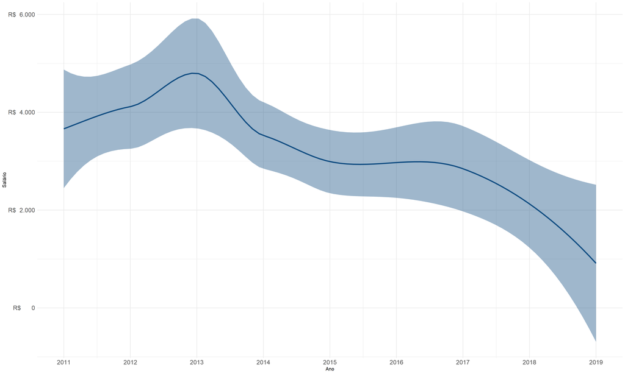

Figura 2: Distribuição da remuneração mensal média dos formados por ano de saída

Se você é o coordenador do curso ou diretor da unidade e gostaria de ter acesso a este relatório personalizado, entre em contato conosco no email dai@unb.br.

[figure not shown]